# Contact Experiment Data Analysis

#First Step is to load the necessary package, If you dont have them just install them. For jjstatsplot you need to install it remotely. #Just remove the dash and press enter. Then Press 3 (none package to be updated).

```r
#remotes::install_github("sbalci/jjstatsplot") #Press 3 !!!!! i.e., installing/Updating none package!
library(psych)
library(jmv)
library(datasets)
library(plyr)
library(readr)
library(dataframes2xls)
library(data.table)
library(plyr)
library(ggstatsplot)
library(jjstatsplot)
library(lme4)
library(lmerTest)
library(ggplot2)
library(rstatix)
library(coin)
library(ARTool)
library(ggpubr)
library(tidyverse)
library(dplyr)
library("afex")
library("emmeans")
library("multcomp")
library(tinytex)
library(rsconnect)
library(shiny)
library(meta)
library(DescTools)
library(dplyr)
```

#Import and merge all the csv files (x.csv where x = ID) of the folder. Note that the ID is has already been added as column

```r
data <- list.files(path = "C:/Users/pkourtes/Desktop/ContactExperiment/Results/Participants/MergingFolder",     # Identify all csv files in folder
                       pattern = "*.csv", full.names = TRUE) %>%
  lapply(read_csv) %>%                                            # Store all files in list
  bind_rows                                                       # Combine data sets into a single data set
data
```

Discard first X trials per interpenetration feedback condition and then create a summary table for each participant. You need to define **nrTrialsPerBlockToRemove**.

```r
data$Part <- as.factor(data$Block < 4)
levels(data$Part)
```

```
[1] "FALSE" "TRUE"
```

```r
data$Part <- factor(data$Part,levels = c("TRUE","FALSE"),
                  labels = c("Part 1","Part 2"))

nrTrialsPerBlockToRemove <- 1
#trialsToRemove <- seq(from = 1, to = nrTrialsPerBlockToRemove)

  data <-  data %>%
    group_by(ID, Part, InterpenetrationFeedback, FullyShaded) %>% # I have added here the fully shaded
    slice(nrTrialsPerBlockToRemove+1:n())
  # to double check we are discarding the right rows
  #print(data[[i]]$Trial)

 # This df will be used to create the subsets for 1st part and 2nd part of the experiment.

data$InterpenetrationFeedback  <- as.factor(data$InterpenetrationFeedback)
data$FullyShaded <- as.factor(data$FullyShaded)
```

```r
ParsiDF <- data


# Exclude the IDs which produced the extreme values (i.e., = or > 3 coefficients from the mean)
ParsiDF$ID[ParsiDF$ID == 9] <- NA
ParsiDF$ID[ParsiDF$ID == 17] <- NA
ParsiDF$ID[ParsiDF$ID == 20] <- NA

ParsiDF <- na.omit(ParsiDF)



ParsiDF <- aggregate(. ~ ID + Age + Gender + InterpenetrationFeedback + Part, ParsiDF, mean)
describe(ParsiDF)
```

[output not shown]

#Let’s visualize the data per interpenetration feedback and/or part of the experiment (part 1 & part 2).

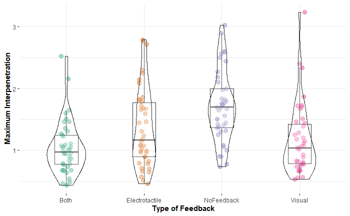

```r
ParsiDFplots <- data # A dataframe just for the plots, so we show everything in real numbers and in centimeters!
ParsiDFplots$ID[ParsiDFplots$ID == 9] <- NA
ParsiDFplots$ID[ParsiDFplots$ID == 17] <- NA
ParsiDFplots$ID[ParsiDFplots$ID == 20] <- NA
ParsiDFplots <- na.omit(ParsiDFplots)
ParsiDFplots <- aggregate(. ~ ID + Age + Gender + InterpenetrationFeedback + Part, ParsiDFplots, mean)

ParsiDFplots$AverageInterpenetration <-100 * ParsiDFplots$AverageInterpenetration #Converting meters to centimeters
ParsiDFplots$MaxInterpenetration <- 100 * ParsiDFplots$MaxInterpenetration #Converting meters to centimeters

p1 <- ggstatsplot::ggbetweenstats(
  data = ParsiDFplots,
  x = "InterpenetrationFeedback", #Indepedent Variable
  y = "MaxInterpenetration", # Depedent Variable
  grouping.var = "Part", # 2nd IV
  type = "p", # parametric test i.e., p values
  pairwise.comparisons = FALSE, #compute pairwise comparisons
  pairwise.display = "significant", # show only the significant ones
  p.adjust.method = "bonferroni", # correction of p-value
  effsize.type = "unbiased", # Calculates the Hedge's g for t tests and the partial Omega for ANOVA
  results.subtitle = FALSE,
  xlab = "Type of Feedback", #label of X axis
  ylab = "Maximum Interpenetration", #label of y axis
  sample.size.label = FALSE,
  var.equal = TRUE, #Assuming Equal variances
  mean.plotting = FALSE,
  mean.ci = TRUE, #display the confidence interval of the mean
  paired = TRUE, #indicating that we have a within subject design
  title.text = "Interpenetration Box-Violin Plots",
  caption.text = "Note: Interpenetration distance is displayed in cm.",
  title.color = "black",
  caption.color = "black"
  )

p2 <- ggstatsplot::ggbetweenstats(
  data = ParsiDFplots,
  x = "InterpenetrationFeedback",
  y = "AverageInterpenetration",
  grouping.var = "Part",
  type = "p",
  pairwise.comparisons = FALSE,
  pairwise.display = "significant",
  p.adjust.method = "bonferroni",
  effsize.type = "unbiased",
  results.subtitle = FALSE,
  xlab = "Type of Feedback",
  ylab = "Average Interpenetration",
  sample.size.label = FALSE,
  var.equal = TRUE,
  mean.plotting = FALSE,
  mean.ci = TRUE,
  paired = TRUE,
  title.text = "Interpenetration Box-Violin Plots",
  caption.text = "Note: Interpenetration distance is displayed in cm.",
  title.color = "black",
  caption.color = "black"
)


# Replicating the above but this time we look on the effect of the type of feedback on the DVs in 1st and 2nd Part of the experiment individually
p3 <- ggstatsplot::grouped_ggbetweenstats(
  data = ParsiDFplots,
  x = "InterpenetrationFeedback",
  y = "MaxInterpenetration",
  grouping.var = "Part",
  type = "p",
  pairwise.comparisons = FALSE,
  pairwise.display = "significant",
  p.adjust.method = "bonferroni",
  effsize.type = "unbiased",
  results.subtitle = FALSE,
  xlab = "Type of Feedback",
  ylab = "Maximum Interpenetration",
  sample.size.label = FALSE,
  var.equal = TRUE,
  mean.plotting = FALSE,
  mean.ci = TRUE,
  paired = TRUE,
  title.text = "Interpenetration Box-Violin Plots",
  caption.text = "Note: Interpenetration distance is displayed in cm.",
  title.color = "black",
  caption.color = "black"
  )

p4 <- ggstatsplot::grouped_ggbetweenstats(
  data = ParsiDFplots,
  x = "InterpenetrationFeedback",
  y = "AverageInterpenetration",
  grouping.var = "Part",
  type = "p",
  pairwise.comparisons = FALSE,
  pairwise.display = "significant",
  p.adjust.method = "bonferroni",
  effsize.type = "unbiased",
  results.subtitle = FALSE,
  xlab = "Type of Feedback",
  ylab = "Average Interpenetration",
  sample.size.label = FALSE,
  var.equal = TRUE,
  mean.plotting = FALSE,
  mean.ci = TRUE,
  paired = TRUE,
  title.text = "Interpenetration Box-Violin Plots",
  caption.text = "Note: Interpenetration distance is displayed in cm.",
  title.color = "black",
  caption.color = "black"
)

# Lets check the effect of shaded condition on DVs
p5 <- ggstatsplot:: ggbetweenstats(
  data = ParsiDFplots,
  x = "Part",
  y = "MaxInterpenetration",
  grouping.var = "InterpenetrationFeedback",
  type = "p",
  pairwise.comparisons = FALSE,
  pairwise.display = "significant",
  p.adjust.method = "bonferroni",
  effsize.type = "unbiased",
  results.subtitle = FALSE,
  xlab = "Order",
  ylab = "Maximum Interpenetration",
  sample.size.label = FALSE,
  var.equal = TRUE,
  mean.plotting = FALSE,
  mean.ci = TRUE,
  paired = TRUE,
  title.text = "Interpenetration Box-Violin Plots",
  caption.text = "Note: Interpenetration distance is displayed in cm.",
  title.color = "black",
  caption.color = "black"
  )

p6 <- ggstatsplot::ggbetweenstats(
  data = ParsiDFplots,
  x = "Part",
  y = "AverageInterpenetration",
  grouping.var = "InterpenetrationFeedback",
  type = "p",
  pairwise.comparisons = FALSE,
  pairwise.display = "significant",
  p.adjust.method = "bonferroni",
  effsize.type = "unbiased",
  results.subtitle = FALSE,
  xlab = "Order",
  ylab = "Average Interpenetration",
  sample.size.label = FALSE,
  var.equal = TRUE,
  mean.plotting = FALSE,
  mean.ci = TRUE,
  paired = TRUE,
  title.text = "Interpenetration Box-Violin Plots",
  caption.text = "Note: Interpenetration distance is displayed in cm.",
  title.color = "black",
  caption.color = "black"
)

p7 <- ggstatsplot::grouped_ggbetweenstats(
  data = ParsiDFplots,
  x = "Part",
  y = "MaxInterpenetration",
  grouping.var = "InterpenetrationFeedback",
  type = "p",
  pairwise.comparisons = FALSE,
  pairwise.display = "significant",
  p.adjust.method = "bonferroni",
  effsize.type = "unbiased",
  results.subtitle = FALSE,
  xlab = "Order",
  ylab = "Maximum Interpenetration",
  sample.size.label = FALSE,
  var.equal = TRUE,
  mean.plotting = FALSE,
  mean.ci = TRUE,
  paired = TRUE,
  title.text = "Interpenetration Box-Violin Plots",
  caption.text = "Note: Interpenetration distance is displayed in cm.",
  title.color = "black",
  caption.color = "black")

p8 <- ggstatsplot::grouped_ggbetweenstats(
  data = ParsiDFplots,
  x = "Part",
  y = "AverageInterpenetration",
  grouping.var = "InterpenetrationFeedback",
  type = "p",
  pairwise.comparisons = FALSE,
  pairwise.display = "significant",
  p.adjust.method = "bonferroni",
  effsize.type = "unbiased",
  results.subtitle = FALSE,
  xlab = "Order",
  ylab = "Average Interpenetration",
  sample.size.label = FALSE,
  var.equal = TRUE,
  mean.plotting = FALSE,
  mean.ci = TRUE,
  paired = TRUE,
  title.text = "Interpenetration Box-Violin Plots",
  caption.text = "Note: Interpenetration distance is displayed in cm.",
  title.color = "black",
  caption.color = "black"
  )
p1
```

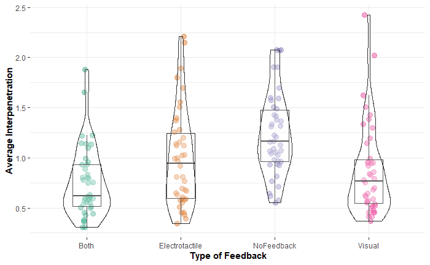

```r
p2
```

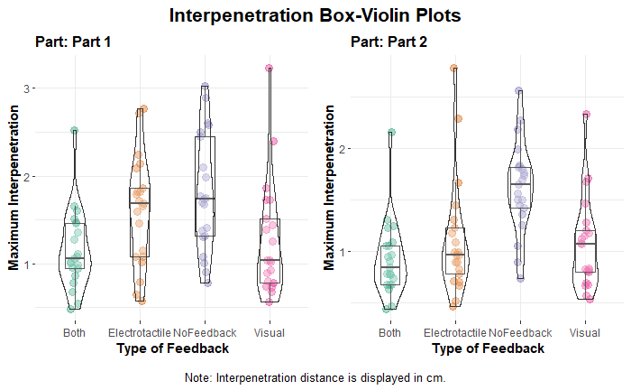

```r
p3
```

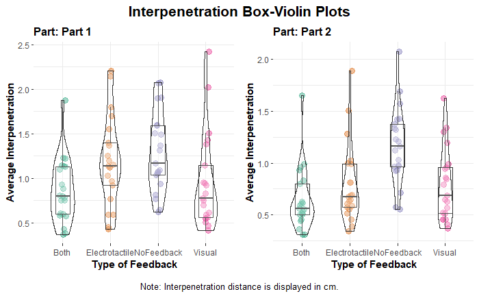

```r
p4
```

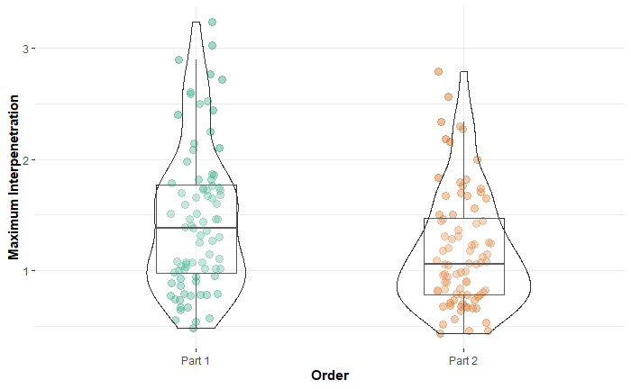

```r
p5
```

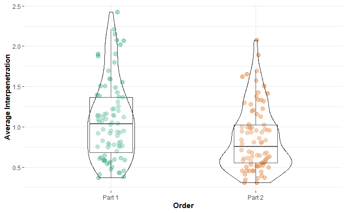

```r
p6
```

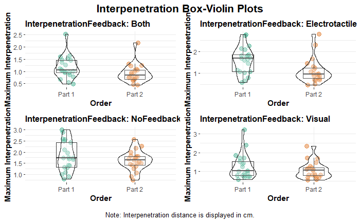

```r
p7
```

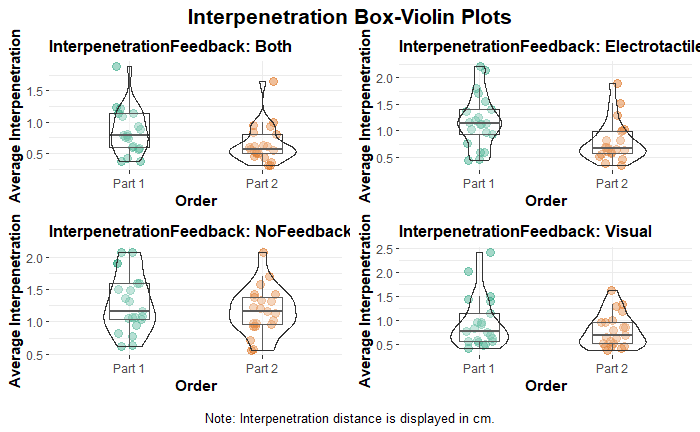

```r
p8
```

```r
NA
NA
```

Let’s check the Two Way Repeated Measures ANOVA

```r
aMax <- aov_ez("ID", "MaxInterpenetration", ParsiDF,
             within = c("Part", "InterpenetrationFeedback"),
             anova_table = list(es = "pes"))

knitr::kable(nice(aMax$anova_table))
```

[output not shown]

```r
aAv <- aov_ez("ID", "AverageInterpenetration", ParsiDF,
             within = c("Part", "InterpenetrationFeedback"),
             anova_table = list(es = "pes"))

knitr::kable(nice(aAv$anova_table))
```

[output not shown]

#The Effect Sizes of the above ANOVAs: 1) Max Interpenetration 2) Average Interpenetration

```r
effectsize::omega_squared(aMax, partial = TRUE, ci = 0.95)

effectsize::omega_squared(aAv, partial = TRUE, ci = 0.95)
```

[output not shown]

#We can see that every type of feedback as well as the interrelationship with the part of the experiment have a large effect on DVs!!!!!!

#Reference for interpreting Omega Squared

#Small effect: ω2 = 0.01;

#Medium effect: ω2 = 0.06;

#Large effect: ω2 = 0.14.

Let’s plot the main effects (Interpenetration Feedback OR Part of the experiment).

```
NOTE: Results may be misleading due to involvement in interactions
```

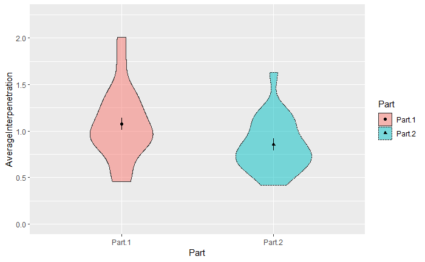

```r
afex_plot(aAvPlots, x = "Part", error = "within",
                mapping = c("linetype", "shape", "fill"),
                data_geom = geom_violin ,
                data_arg = list(width = 0.5))  +
            ylim(0, 2.25)
```

Let’s plot the main interaction effects (Interpenetration Feedback AND Part of the experiment).

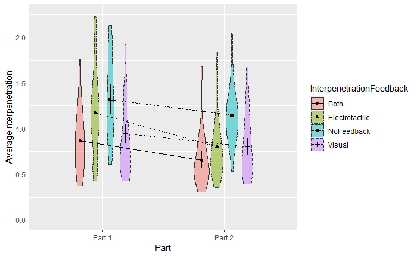

Post-hoc Tests

```r
################################# Maximum Interpenetration #######################
aMaxemm <- emmeans(aMax,~ Part:InterpenetrationFeedback,
 method="pairwise", interaction=TRUE, adjust = "bonf")

pairs(aMaxemm, adjust = "bonf")

require(esvis)
EffectSizeMax <- hedg_g(ParsiDF,MaxInterpenetration ~ InterpenetrationFeedback + Part, keep_d = FALSE) #Calculates the hedge's g per pair!

EffectSizeMax


################################# Average Interpenetration #######################
aAvemm <- emmeans(aAv,~ Part:InterpenetrationFeedback,
 method="pairwise", interaction= TRUE, adjust = "bonf")

pairs(aAvemm, adjust = "bonf")

EffectSizeAv <- hedg_g(ParsiDF,AverageInterpenetration ~ InterpenetrationFeedback + Part, keep_d = FALSE)
EffectSizeAv



############ Change in the Performance (Part 1 vs Part2) per Interpenetration Feedback #############

contrast(emmeans(aMax,~ Part:InterpenetrationFeedback),
         method="pairwise", interaction=TRUE, adjust = "bonf")

contrast(emmeans(aAv,~ Part:InterpenetrationFeedback),
         method="pairwise", interaction=TRUE, adjust = "bonf")

#Calculating the effect sizes of the significant comparisons
require(esc)
hedges_g(d = 0.63133007, totaln = 60)
hedges_g(d = 0.60334460, totaln = 60)
hedges_g(d = 0.64937334, totaln = 60)
hedges_g(d = 0.60831571, totaln = 60)
```

[output not shown]

#### For Maximum Interpenetration

#### Significant Comparisons:

#Part.1 Both - Part.2 Both p = 0.0039 Hedge’s g = 0.61676553

#Part.1 Both - Part.1 Electrotactile p = 0.0014 Hedge’s g = -0.72831779

#Part.1 Both - Part.1 NoFeedback p <.0001 Hedge’s g = -1.16801037

#Part.2 Both - Part.2 NoFeedback p <.0001 Hedge’s g = -1.79394003

#Part.1 Electrotactile - Part.2 Electrotactile p <.0001 Hedge’s g = 0.81636215

#Part.1 Electrotactile - Part.1 Visual p = 0.0100 Hedge’s g = 0.58901263

#Part.2 Electrotactile - Part.2 NoFeedback p <.0001 Hedge’s g = -1.11877925

#Part.1 NoFeedback - Part.1 Visual p <.0001 Hedge’s g = 0.98702238

#Part.2 NoFeedback - Part.2 Visual p <.0001 Hedge’s g = 1.26405828

#Hedge’s G Interpretation (Note: + or - just shows the direction!):

#Small effect (cannot be discerned by the naked eye) = 0.2

#Medium Effect = 0.5

#Large Effect (can be seen by the naked eye) = 0.8

#### For Average Interpenetration

#### Significant Comparisons:

#Part.1 Both - Part.2 Both p = 0.0004 Hedge’s g = 0.688559174

#Part.1 Both - Part.1 Electrotactile p = 0.0024 Hedge’s g = -0.673535198

#Part.1 Both - Part.1 NoFeedback p < .0001 Hedge’s g = -1.102751598

#Part.2 Both - Part.2 NoFeedback p < .0001 Hedge’s g = -1.688918621

#Part.1 Electrotactile - Part.2 Electrotactile p < .0001 Hedge’s g = 0.855157215

#Part.1 Electrotactile - Part.1 Visual p = 0.0258 Hedge’s g = 0.524527360

#Part.2 Electrotactile - Part.2 NoFeedback p < .0001 Hedge’s g = -1.095756543

#Part.1 NoFeedback - Part.1 Visual p < .0001 Hedge’s g = 0.901187692

#Part.2 NoFeedback - Part.2 Visual p < .0001 Hedge’s g = 1.096379269

#Key Findings:

#Electrotactile in Part 1 has significant differences against Visual and combined feedback (moderate effects), while is not significant different from No Feedback.

#However, in part 2, Electrotactile is significant different from No Feedback, while it does not show significant differences against Visual and Combined feedback.

#Both (i.e., combined) and Visual feedback are significantly different against No Feedback in part 1 and part 2.

#Notably, ONLY Both (combined) and Electrotactile feedback show a significant improvement from part 1 to part 2.

#This explains why the comparison between combined feedback against No Feedback has far greater effect size in part 2.

#Importantly, this explains why the Electrotactile feedback becomes significantly different against No Feedback in part 2, as well as the absence of differences against Visual and Combined.

#Since the Visual and No feedback do not improve in part 2 (i.e, no differences between part 1 and part 2), we may infer that the practice/order effect does not affect significantly the performance.

#Also, since the Visual feedback do not improve in part 2, then we may infer that the significant improvement that we observe for combined feedback in part 2 (i.e., part 1 vs part 2) is predominantly attributed to the improvement of the electrotactile feedback.

#Hence, either the calibration of, or the familiarization with, or both, concerning the electrotactile feedback, is the reason that we observe these effects of electrotactile and combined feedback in part 2.

##### Regarding the change of the performance for each type of interpenetration feedback between part 1 and part 2 of the experiment!

#### we can see that for MAX INTERPENETRATION the significant comparisons are:

#1) Part.1 - Part.2 Electrotactile - NoFeedback p = 0.0066 Hedge’s g = 0.623131

#2) Part.1 - Part.2 Electrotactile - Visual p = 0.0105 Hedge’s g = 0.595509

#This means that the improvement of the performance from part 1 to part 2 regarding the maximum interpenetration was significantly greater for the “Electrotactile Feedback” compared to the “No Feedback” and “Visual Feedback” respectively! (Medium to Large effects)

#The rest of the comparisons were insignificant!

#Hedge’s G Interpretation (Note: + or - just shows the direction!):

#Small effect (cannot be discerned by the naked eye) = 0.2

#Medium Effect = 0.5

#Large Effect (can be seen by the naked eye) = 0.8

#For the AVERAGE INTERPENETRATION the significant comparisons are:

#1) Part.1 - Part.2 Electrotactile - NoFeedback p = 0.0049 Hedge’s g = 0.6409399

#2) Part.1 - Part.2 Electrotactile - Visual p = 0.0097 Hedge’s g = 0.6004155

#This means that the improvement of the performance from part 1 to part 2 regarding the average interpenetration was significantly greater for the “Electrotactile Feedback” compared to the “No Feedback” and “Visual Feedback” respectively! (Medium to Large effects)

#The rest of the comparisons were insignificant!

Intensities of the Electrotactile Feedback

```r
library(readr)

intensities <- read_csv("C:/repos/contactExperimentRNotebook/intensities.csv")

pairwise_t_test(data = intensities, Sensation ~ Calibration, p.adjust.method = "bonferroni", paired = TRUE, alternative = "two.sided", detailed = TRUE)

pairwise_t_test(data = intensities, Pain ~ Calibration, p.adjust.method = "bonferroni", paired = TRUE, alternative = "two.sided", detailed = TRUE)

pairwise_t_test(data = intensities, ActualValue ~ Calibration, p.adjust.method = "bonferroni", paired = TRUE, alternative = "two.sided", detailed = TRUE)
```

[output not shown]

#OK, for every DV (i.e., Sensation, Pain , and Actual Value) we have the same results

#Significant differences between

#Final and Initial !!!!!!

#Middle and Initial !!!!!!

#Non-Significant differences between

#Middle and Final calibration

#Let’s check the effect sizes of the significant comparisons (i.e, Final vs Initial, Midlle vs Initial) now.

```r
MidVSInitial <- filter(intensities, Calibration != "final")

FinalVSInitial <- filter(intensities, Calibration != "middle")

effectsize::hedges_g("Sensation", "Calibration", data = MidVSInitial, correction = TRUE, paired = TRUE,)

effectsize::hedges_g("Pain", "Calibration", data = MidVSInitial, correction = TRUE, paired = TRUE,)

effectsize::hedges_g("ActualValue", "Calibration", data = MidVSInitial, correction = TRUE, paired = TRUE,)

effectsize::hedges_g("Sensation", "Calibration", data = FinalVSInitial, correction = TRUE, paired = TRUE,)

effectsize::hedges_g("Pain", "Calibration", data = FinalVSInitial, correction = TRUE, paired = TRUE,)

effectsize::hedges_g("ActualValue", "Calibration", data = FinalVSInitial, correction = TRUE, paired = TRUE,)
```

[output not shown]

#The + or - is just the direction of the SDs change proportionally to how the comparison is called (e..g, Final vs Initial or Initial vs Final) so just ignore it.

#The important is the value of hedges g.

#We have a Large (or a Very large in some) Effect in every significant comparison.

#Hedge’s G Interpretation:

#Small effect (cannot be discerned by the naked eye) = 0.2

#Medium Effect = 0.5

#Large Effect (can be seen by the naked eye) = 0.8

Let’s visualize the comparisons

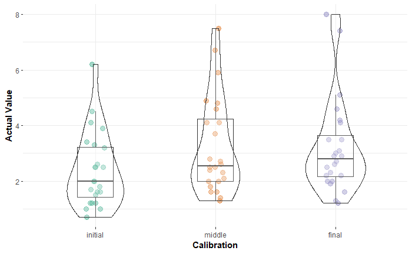

Checking if the results on the performance may be due to ineffective initial calibration and not due to familiriazation with electrotactile feedback.

```r
require(data.table)
setDT(intensities)

intensities_wide <- dcast(intensities,ParticipantID ~ Calibration, value.var=c("Sensation", "Pain","ActualValue"))

intensities_wide$DiffSensation <- intensities_wide$Sensation_middle - intensities_wide$Sensation_initial

intensities_wide$DiffPain <- intensities_wide$Pain_middle - intensities_wide$Pain_initial

intensities_wide$DiffActual <- intensities_wide$ActualValue_middle - intensities_wide$ActualValue_initial



identify_outliers(intensities_wide, variable = "DiffSensation", coef = 1.5)

identify_outliers(intensities_wide, variable = "DiffPain", coef = 1.5)

identify_outliers(intensities_wide, variable = "DiffActual", coef = 1.5)

require(psych)
describe.by(intensities_wide$DiffSensation)
describe.by(intensities_wide$DiffPain)
describe.by(intensities_wide$DiffActual)

#IDs 12 and 19 seem suspicious, however the rest are seem ok
#lets exclude them and rerun the analyses

intensities$ParticipantID[intensities$ParticipantID == 19] <- NA
intensities$ParticipantID[intensities$ParticipantID == 12] <- NA

intensities <- na.omit(intensities)

pairwise_t_test(data = intensities, Sensation ~ Calibration, p.adjust.method = "bonferroni", paired = TRUE, alternative = "two.sided", detailed = TRUE)

pairwise_t_test(data = intensities, Pain ~ Calibration, p.adjust.method = "bonferroni", paired = TRUE, alternative = "two.sided", detailed = TRUE)

pairwise_t_test(data = intensities, ActualValue ~ Calibration, p.adjust.method = "bonferroni", paired = TRUE, alternative = "two.sided", detailed = TRUE)

#OK, we have similar results, lets go a wee bit farther
# I will also exclude the IDs which were not included in the performance analyses.

intensities$ParticipantID[intensities$ParticipantID == 9] <- NA
intensities$ParticipantID[intensities$ParticipantID == 17] <- NA
intensities$ParticipantID[intensities$ParticipantID == 20] <- NA
intensities <- na.omit(intensities)

pairwise_t_test(data = intensities, Sensation ~ Calibration, p.adjust.method = "bonferroni", paired = TRUE, alternative = "two.sided", detailed = TRUE)

pairwise_t_test(data = intensities, Pain ~ Calibration, p.adjust.method = "bonferroni", paired = TRUE, alternative = "two.sided", detailed = TRUE)

pairwise_t_test(data = intensities, ActualValue ~ Calibration, p.adjust.method = "bonferroni", paired = TRUE, alternative = "two.sided", detailed = TRUE)
```

[output not shown]

#OK, we have similar results again. So, it doesn’t seem that for the lower performance in the 1st part the reason was an inappropriate calibration. On the other hand, a familiarization with the electrotactile feedback seems to explain better the difference in the performance between part 1 and part 2. To clarify, by familiarization I mean the acceptance of the electrotactile feedback (e.g., it doesnt startle or frighten the user) as well as the cognitive association (in psychological terms: conditioning, or in game terms: game mechanics) between an X event (e.g., when I feel that) and Y action (e.g., then I stop or I adjust the position of my hand).

Questionnaires

#Now let’s check the questionnaires’ results

#For Questionnaires is better to compare the medians (i.e., non-parametric tests) because the responses are not real numbers, the responses are ordinal data which may be better interpreted as ranks.

```r
quest <- read_csv("C:/repos/contactExperimentRNotebook/Questionnaires.csv")

#Lets check the median and the mode of the responses (These should be reported in a table)
#TableQuestionnaire <-

median(quest$VisualUseful)
Mode(quest$VisualUseful)

median(quest$ElectrotactileUseful)
Mode(quest$ElectrotactileUseful)

median(quest$VisualCoherent)
Mode(quest$VisualCoherent)

median(quest$RelyingMoreOn)
Mode(quest$RelyingMoreOn)

median(quest$ElectricalCoherent)
Mode(quest$ElectricalCoherent)

median(quest$VisualResembling)
Mode(quest$VisualResembling)

median(quest$ModalitiesSynchronized)
Mode(quest$ModalitiesSynchronized)

median(quest$ElectrotactileResembling)
Mode(quest$ElectrotactileResembling)

median(quest$CombinedResembling)
Mode(quest$CombinedResembling)


#Usefulness
wilcox.test(quest$VisualUseful, quest$ElectrotactileUseful,
                           alternative = "two.sided",
                           paired = TRUE,
                           exact = FALSE,
                           correct = FALSE,
                           conf.int = TRUE,
                           data = quest)

#Coherence
wilcox.test(quest$VisualCoherent, quest$ElectricalCoherent,
                           alternative = "two.sided",
                           paired = TRUE,
                           exact = FALSE,
                           correct = FALSE,
                           conf.int = TRUE,
                           data = quest)

#Resemblance
wilcox.test(quest$VisualResembling, quest$ElectrotactileResembling,
                           alternative = "two.sided",
                           paired = TRUE,
                           exact = FALSE,
                           correct = FALSE,
                           conf.int = TRUE,
                           data = quest)


#No differences!
###### Let's check on which type of feedback the users relied upon more

#Includes Visual, Both, Electrotactile. Values: 0 or 1
Reliance <- read_csv("C:/repos/contactExperimentRNotebook/reliance.csv")
Reliance$Type <- factor(Reliance$Type, levels = c("Both", "Visual", "Electrotactile"))
pairwise.wilcox.test(Reliance$Reliance, Reliance$Type, alternative = "greater",p.adjust.method = "bonferroni")


#Includes Visual and Electrotactile. Values: 0,1,2,3
RelianceMore <- read_csv("C:/repos/contactExperimentRNotebook/relianceMore.csv")
RelianceMore<- dcast(RelianceMore,ID ~ TypeMore, value.var= "RelianceMore")
wilcox.test(RelianceMore$Electrotactile, RelianceMore$Visual,
                           alternative = "greater",
                           paired = TRUE,
                           exact = FALSE,
                           correct = FALSE,
                           conf.int = TRUE,
                           data = RelianceMore)
###### Let's check which resembled better touching a surface
Resemble <- read_csv("C:/repos/contactExperimentRNotebook/resemblance3factors.csv")
pairwise.wilcox.test(Resemble$Resemblance, Resemble$Type, p.adjust.method = "bonferroni")
```

[output not shown]

#Note for the interpertation:

#Median: The median value is the number that is in the middle, with the same amount of numbers below and above.

#Mode: The mode is the most commonly/frequently observed value in a set of data (i.e., the most frequent response)

Visual

#Usefulness

#Median:5.5

#Mode: 5

#Interpertation: Useful

#Coherence

#Median:5

#Mode: 5

#Interpertation: Coherent

#Resemblance

#Median:3

#Mode: 3

#Interpertation: Different

Electrotactile

#Usefulness

#Median:6

#Mode: 5 (8 Response)

#Interpertation: Useful to Very Useful

#Coherence

#Median:5

#Mode: 5

#Interpertation: Coherent

#Resemblance

#Median: 2.5

#Mode: 1 (8 responses)

#Interpertation: Different to Extremely Different

Combined

#Usefulness (Rely more on visual or electrotactile)

#Median:4.5 (i.e., half of the responses indicated > 4 which means 12 preferred the electrotactile since 5-7 corresponds to electrotactile. Note that < 4.5, means that the other 12 responses were for both visual and combined feedback. combined = 4, while visual = 1 - 3)

#Mode: 3 (9 Responses)

#Interpertation: Ballanced, however it leans towards Electrotactile

#Modalities synchronized

#Median:6

#Mode: 7

#Interpertation: Very Coherent to Completely Coherent

#Resemblance

#Median:4

#Mode: 5

#Interpertation: Moderately Similar to Similar

Comparisons

#1) In Terms of Usefulness, Coherence, and resemblance

#There are not significant differences between Combined, Visual, and Electrotatcile feedback, which replicates our findings on the users’ performance in part 2, where we did not find any significant differences as well. In combination with the medians and modes for each question (see above), we may infer that electrotactile feedback was equivalent to visual feedback, as well as it received positive evaluations by the users especially in terms of usefulness and coherence.

# Resemblance Part2

#Regarding the electrotactile feedback, our findings replicate the findings of previous studies which found that the sensation of touching provided by electrotactile feedback substantially deviates from the sensation of touching in real world.

#Now, Let’s visualize the data

```r
#Visualization of the responses in terms of Usefulness, Coherence, and Resemblance

visualVSelectro <- read_csv("C:/repos/contactExperimentRNotebook/visualVSelectro.csv")
?ggbetweenstats()
p12 <- ggstatsplot::ggbetweenstats(
  data = visualVSelectro,
  x = "Type",
  y = "Usefulnes",
  type = "np",
  pairwise.comparisons = FALSE,
  pairwise.display = "significant",
  p.adjust.method = "bonferroni",
  effsize.type = "unbiased",
  results.subtitle = FALSE,
  xlab = "Type of Feedback",
  ylab = "Usefulness",
  sample.size.label = FALSE,
  var.equal = FALSE,
  mean.plotting = FALSE,
  mean.ci = TRUE,
  paired = TRUE,
  title.text = "Usefulness Box-Violin Plots",
  title.color = "black",
  caption.color = "black"
  )
p12

p13 <- ggstatsplot::ggbetweenstats(
  data = visualVSelectro,
  x = "Type",
  y = "Resemblance",
  type = "np",
  pairwise.comparisons = FALSE,
  pairwise.display = "significant",
  p.adjust.method = "bonferroni",
  effsize.type = "unbiased",
  results.subtitle = FALSE,
  xlab = "Type of Feedback",
  ylab = "Resemblance",
  sample.size.label = FALSE,
  var.equal = FALSE,
  mean.plotting = FALSE,
  mean.ci = TRUE,
  paired = TRUE,
  title.text = "Resemblance Box-Violin Plots",
  title.color = "black",
  caption.color = "black"
  )
p13

p14 <- ggstatsplot::ggbetweenstats(
  data = visualVSelectro,
  x = "Type",
  y = "Coherence",
  type = "np",
  pairwise.comparisons = FALSE,
  pairwise.display = "significant",
  p.adjust.method = "bonferroni",
  effsize.type = "unbiased",
  results.subtitle = FALSE,
  xlab = "Type of Feedback",
  ylab = "Coherence",
  sample.size.label = FALSE,
  var.equal = FALSE,
  mean.plotting = FALSE,
  mean.ci = TRUE,
  paired = TRUE,
  title.text = "Coherence Box-Violin Plots",
  title.color = "black",
  caption.color = "black"
  )
p14


Preferences <- read_csv("C:/repos/contactExperimentRNotebook/prefFeed.csv")
#This will show on which type of feedback the users relied upon more
ggplot(Preferences) + geom_bar(aes(x = Preferences$Type))
#This will show on which type of feedback the users relied upon more
hist(quest$RelyingMoreOn)
p15 <- ggstatsplot::ggbetweenstats(
  data = Reliance,
  x = "Type",
  y = "Reliance",
  type = "np",
  pairwise.comparisons = FALSE,
  pairwise.display = "significant",
  p.adjust.method = "bonferroni",
  effsize.type = "unbiased",
  results.subtitle = FALSE,
  xlab = "Type of Feedback",
  ylab = "Reliance",
  sample.size.label = FALSE,
  var.equal = FALSE,
  mean.plotting = FALSE,
  mean.ci = TRUE,
  paired = TRUE,
  title.text = "Reliance Box-Violin Plots",
  title.color = "black",
  caption.color = "black"
  )
p15


#This will show which type of feedback resemble better touching a surface
p16 <- ggstatsplot::ggbetweenstats(
  data = Resemble,
  x = "Type",
  y = "Resemblance",
  type = "np",
  pairwise.comparisons = FALSE,
  pairwise.display = "significant",
  p.adjust.method = "bonferroni",
  effsize.type = "unbiased",
  results.subtitle = FALSE,
  xlab = "Type of Feedback",
  ylab = "Resemblance",
  sample.size.label = FALSE,
  var.equal = FALSE,
  mean.plotting = FALSE,
  mean.ci = TRUE,
  paired = TRUE,
  title.text = "Resemblance Box-Violin Plots",
  title.color = "black",
  caption.color = "black"
  )
p16
```

[output not shown]

#The rest of info on the electrotactile feedback from the questionnaires

```r
median(quest$ElectricalSensation)
Mode(quest$ElectricalSensation)
#Moderate i.e., neither pleasant nor annoying
hist(quest$ElectricalSensation)

median(quest$ElectricalUpdatePerception)
Mode(quest$ElectricalUpdatePerception)
# Often, Very often, All the time!
hist(quest$ElectricalUpdatePerception)
```

[output not shown]

#Regarding the perceptual update that the user presses harder the surface, the results are really positive, and postulate that the electrotactile feedback may contribute with strengthening the plausibility illusion (i.e., the illusion that the virtual environment responds to your action). However, this should be meticuously investigated in a future study.